# MEDB 5502, Module 14, review

## Topics to be covered, 1 of 2

- What you will learn
  - 01 Linear regresion, analysis of variance
  - 02 Linear regression with multiple independent variables
  - 03 Analysis of covariance
  - 04 Multi-factor analysis of variance
  - 05 Dimension reduction
  - 06 Logistic regression
  - 07 Diagnostic tests

## Topics to be covered, 2 of 2

- What you will learn
  - 08 Survival analysis
  - 09 Meta-analysis
  - 10 Dark side of data science
  - 11 Hierarchical models
  - 12 Longitudinal data
  - 13 Bayesian statistics

## Module 01, Review

- Simple linear regression
- One factor analysis of variance

## Module 01, SPSS scatterplot

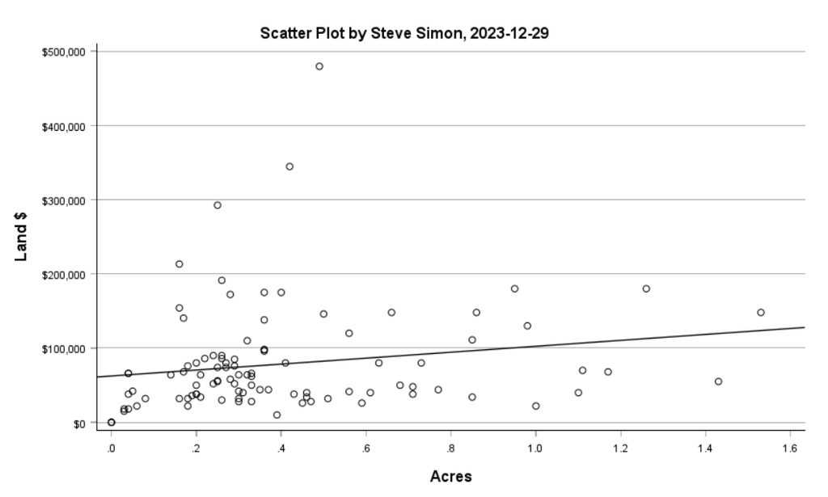

## Module 01, SPSS boxplot

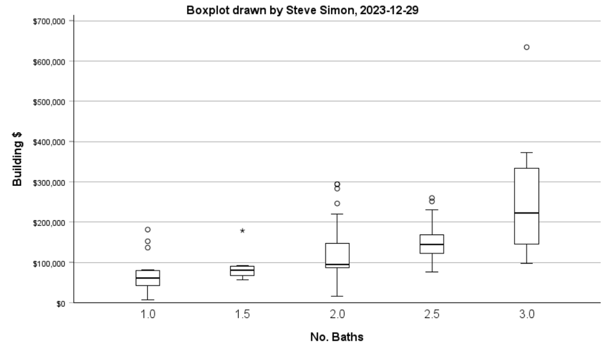

## Module 01, SPSS calculation of R Square

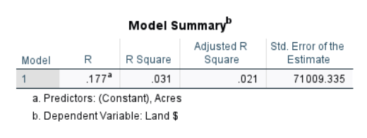

## Module 01, SPSS ANOVA table

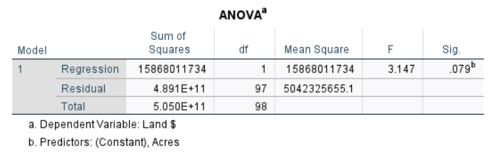

## Module 01, SPSS linear regression coefficients

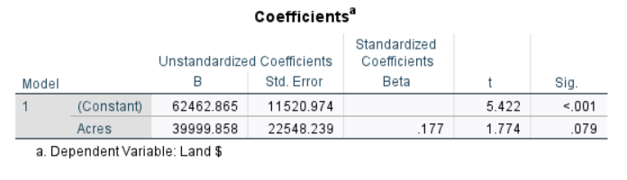

## Break #1

- What you have learned
  - 01 Linear regresion, analysis of variance
- What’s coming next
  - 02 Linear regression with multiple independent variables

## Module 02, Linear regression with multiple independent variables

- Analysis of variance table
  - R-squared
  - Partial F tests
- Stepwise regression
- Interpretation
- Collinearity
- Mediation

## Module 02, Checking assumptions

- Non-normality
  - Q-Q plot of residuals
- Lack of independence
  - Assessed qualitatively
- Unequal variances, Non-linearity
  - Residual scatterplot

## Break #2

- What you have learned
  - 02 Linear regression with multiple independent variables
- What’s coming next
  - 03 Analysis of covariance

## Module 03, Analysis of covariance

- Confounding/covariate imbalance
- Interpretation
- Interactions

## Module 03, Checking assumptions

- Non-normality
  - Q-Q plot of residuals
- Lack of independence
  - Assessed qualitatively
- Unequal variances, Non-linearity
  - Residual scatterplots

## Break #3

- What you have learned
  - 03 Analysis of covariance
- What’s coming next
  - 04 Multi-factor analysis of variance

## Module 04, Multi-factor analysis of variance

- Tukey post hoc test
- Interaction

## Module 04, Checking assumptions

- Non-normality
  - Q-Q plot of residuals
- Lack of independence
  - Assessed qualitatively
- Unequal variances
  - Boxplots

## Break #4

- What you have learned
  - 04 Multi-factor analysis of variance
- What’s coming next
  - 05 Dimension reduction

## Module 05, Dimension reduction

- Principal components analysis
  - Eigenvectors, Eigenvalues
- Factor analysis
  - Factor rotation

## Break #5

- What you have learned
  - 05 Dimension reduction
- What’s coming next
  - 06 Logistic regression

## Module 06, Precursors to logistic regression

- Test of two proportions
- Chi-square test of independence
- Odds ratio versus relative risk

## Module 06, Logistic regression

- Linear on log odds scale
- Assumptions
  - Independence
  - Linearity

## Break #6

- What you have learned
  - 06 Logistic regression
- What’s coming next
  - 07 Diagnostic tests

## Module 07, Diagnostic tests

- Sensitivty, specificity
  - SpPin, SnNout
- Positive/negative predictive value
- Likelihood ratio
- ROC curve

## Break #7

- What you have learned
  - 07 Diagnostic tests
- What’s coming next
  - 08 Survival analysis

## Module 08, Basic survival analysis

- Censoring
- Kaplan-Meier curve
- Log rank test

## Module 08, Cox regression

- Define hazard function
  - Increasing/decreasing/constant hazard
  - Hazard ratio
- Assumptions
  - Independence
  - Non-informative censoring

## Break #8

- What you have learned
  - 08 Survival analysis
- What’s coming next
  - 09 Meta-analysis

## Module 09, Meta-analysis

- Forest plot
- Publication bias
  - Funnel plot
- Heterogeneity
  - Cochran’s Q, I-squared

## Break #9

- What you have learned
  - 09 Meta-analysis
- What’s coming next
  - 10 Dark side of data science

## Module 10, Dark side of data science

- Empiricism
- Reification
- Bias in data science

## Break #10

- What you have learned
  - 10 Dark side of data science
- What’s coming next
  - 11 Hierarchical models

## Module 11, Hierarchical models

- Clustered data
- Between and within cluster variation
  - Intraclass correlation

## Module 11, Checking assumptions

- Independence
  - Only between clusters
- Normality
  - Within clusters
  - Between clusters

## Break #11

- What you have learned
  - 11 Hierarchical models
- What’s coming next
  - 12 Longitudinal data

## Module 12, Longitudinal data

- Random intercepts model
- Random slopes model

## Module 12, Checking assumptions

- Independence
  - Only between subjects
- Normality
  - Residuals
  - Random intercepts/slopes
- Linearity
  - Scatterplot of residuals

## Break #12

- What you have learned
  - 12 Longitudinal data
- What’s coming next
  - 13 Bayesian statistics

## Module 13, Bayesian statistics

- Prior
  - Flat or non-informative prior
- Likelihood
- Posterior

## Summary, 1 of 2

- What you have learned
  - 01 Linear regresion, analysis of variance
  - 02 Linear regression with multiple independent variables
  - 03 Analysis of covariance
  - 04 Multi-factor analysis of variance
  - 05 Dimension reduction
  - 06 Logistic regression
  - 07 Diagnostic tests

## Summary, 2 of 2

- What you have learned
  - 08 Survival analysis
  - 09 Meta-analysis
  - 10 Dark side of data science
  - 11 Hierarchical models
  - 12 Longitudinal data
  - 13 Bayesian statistics